# LADS-EDU Final Project: Fabio Campos, Ofer Chen, Trent Hoy, Varalika Singh

## Data

The data used in this project were generated by ~500 students from Trent’s undergraduate French courses. Trent noted that there are three main language backgrounds represented by his students and that the data might reveal ways to tailor his instruction for each one. We began with a wide range of potential sources (LMS data, discussion forums, online workbook activities, portfolio assignments, etc.) and variables (course level, linguistic background, time spent, assignment content, etc.) and spent much time deliberating about which would be the most useful to examine while not requiring an unreasonable amount of time and effort to retrieve. To guide our decision, we focused on sources that specifically reflected French competency rather than general course engagement.

We ended up selecting 11 variables for our analysis, most of which come from components of the textbook’s online workbook (MHConnect):

Online Adaptive Learning Activities (LearnSmart) * Percent of Questions Answered Correctly (Per_correct) * Percent of Questions Where Student was Aware of Being Correct or Incorrect (Per_aware) * Percent of Questions Where Student was Unaware of Being Incorrect (IU) * Time Spent in Minutes on LearnSmart (Time_LS) * Percent of Assigned LearnSmart Activities Completed (Per_complete_LS)

Online Homework Activities * Time Spent in Minutes on Homework Assignments (Time_hw) * Percent of Homework Questions Answered Correctly (Per_correct_hw) * Time Spent on Optional Pronunciation Exercises (Time_pron)

Other * Final Numeric Course Grade * Linguistic Background * Sex

Each row in the dataframe represents a student and each column, a different variable.

Due to the limitations of certain data formats when retrieved from the MHConnect system, we decided to look exclusively at first-semester students (FRE1120). Furthermore, only those who completed the course and received a final grade were included. After additional cleaning (described below), the final sample consisted of 129 students across six sections of both face-to-face and online FRE1120 courses.

## Question

Armed with this subset of data, we set out to answer two key questions:

1. Can student practice behavior and performance outcomes from the textbook’s online workbook be used to meaningfully group students?
2. If we identify meaningful groups, how can Trent use this analysis to support students in future classes, both within these workbook assignments and other aspects of the course?

## Approach

To answer these questions, we turned to cluster analysis, as this approach allows us to find groups of students who are similar across multiple variables. Additionally, a close examination of the within cluster means for each variable will help us to generate a persona for each cluster. These different personas may be useful for Trent in designing general instruction or specific interventions. We will also be able to examine the demographic breakdowns of each cluster to see if linguistic background or sex play any role in practice behavior or performance outcome.

## Process, Results, & Interpretation

### Data Cleaning

Trent did basic cleaning and organization when compiling and deidentifying the numerous reports from MHConnect, thus we didn’t have a lot of additional cleaning work to do.

Filtering:

- We removed students in sections where LearnSmart activities were not mandatory so as to compare students who had more similar course requirements.
- We predicted that linguistic background would play a significant role in the behaviors and outcomes measured in our analysis. We therefore decided to focus on the three predominant language groups - English, Spanish, and Haitian Creole. Thus, a handful of students with other backgrounds such as Portuguese, Chinese, and French, were removed.

Calculated Variables:

- We created a variable to track the overall percent of correct LearnSmart responses (Per_correct) by adding percent correct and aware and percent correct and unaware.
- We also created a variable to reflect the total percent of awareness of correct/incorrect responses in LearnSmart (Per_aware) by adding percent correct and aware and percent incorrect and aware.

For ease of use, we removed unnecessary columns and renamed columns.

```r
#load relevant libraries
library(dplyr)
library(ggplot2)
#Import data into a new data frame
MasterData<-read.csv("~/downloads/FRE1120 Data Summary - RAW.csv")
#Removing students that were not required to do the LS exercises
MasterData<-MasterData[MasterData$LS.Required=="y",]
#Removing the few students with linguistic background different than English, Spnaish, or Creole due to very low numbers
MasterData<-MasterData[MasterData$Linguistic.Background %in% c("English","Creole","Spanish"),]
#Creating the calculated fields of Per_aware and Per_correct
MasterData <- MasterData %>% mutate(Per_correct = Correct...aware+Correct...unaware)
MasterData <- MasterData %>% mutate(Per_aware = Correct...aware+Incorrect...aware)
#eliminating redundant columns
MasterData<- select(MasterData, "ID..","Sex","Linguistic.Background","Final.Grade","Incorrect...unaware","Per_correct","Per_aware","Time.Spent..HW.","Time.Spent..Pronunciation.Practice.","Time.Spent..LearnSmart.","Total.HW...Correct","Total.LS...Complete",)
#Changing column names
names(MasterData) <- c("ID","Sex","Language","Final_grade","IU","Per_correct","Per_aware","Time_hw","Time_pron","Time_LS","Per_correct_hw","Per_complete_LS")
```

### Variable Exploration

We started looking at the relationships between our variables using the R ‘pairs’ function. We then focused on specific pairs of variables and made note of interesting or unexpected relationships.

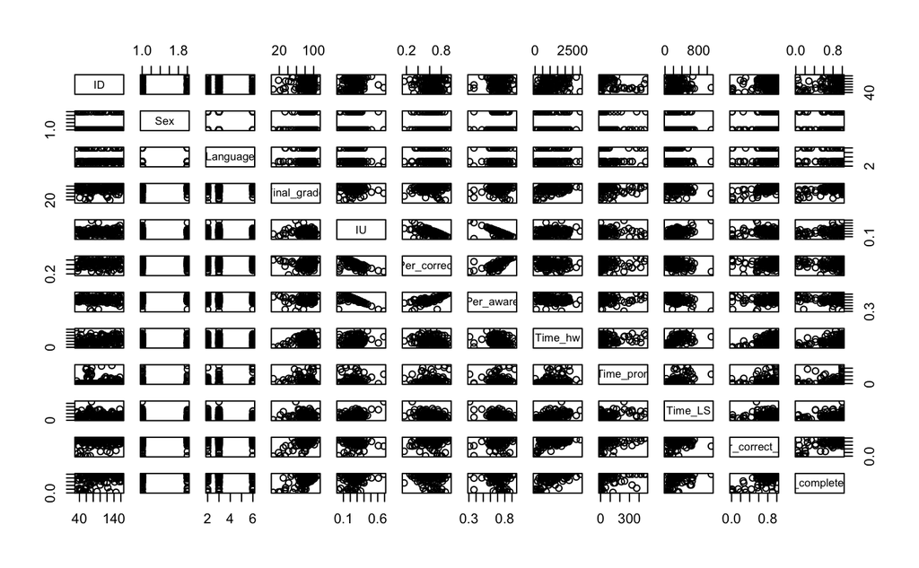

```r
#Examine scatter plots for different variable combination pairs
#Creating scatter plots for all pairs
pairs(MasterData)
```

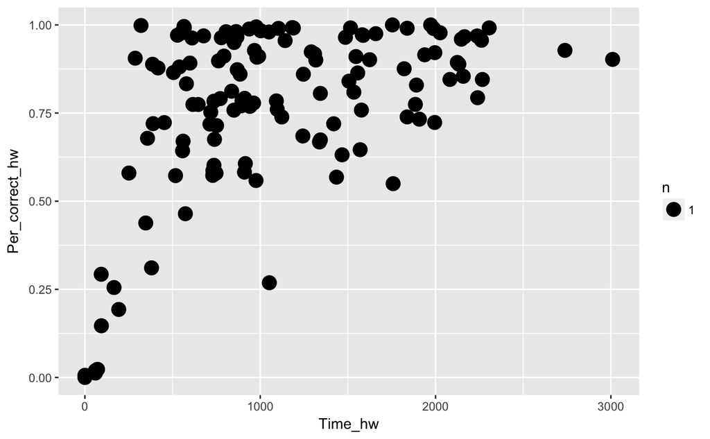

```r
#Time spent on Connect homework, Percentage of correct homework responses
ggplot(MasterData, aes(Time_hw,Per_correct_hw))+ geom_point() + stat_sum(aes(group = 1))
```

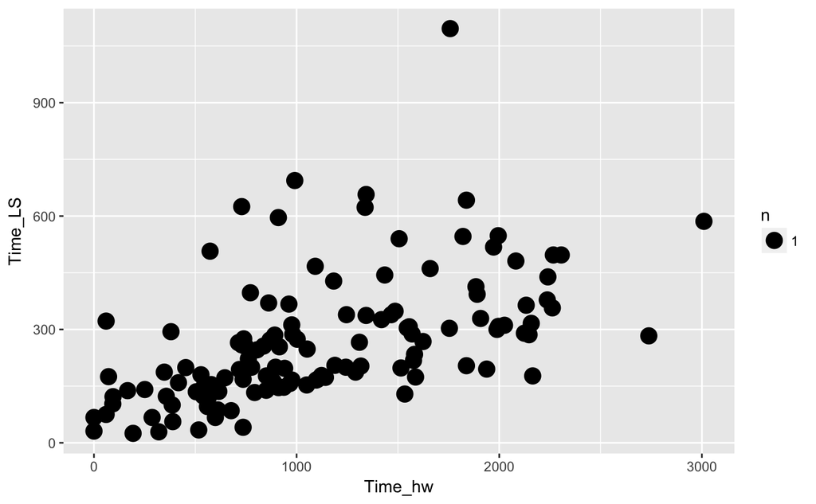

```r
#Time spent on Connect homework, Time spent on LearnSmart adaptive activities
ggplot(MasterData, aes(Time_hw,Time_LS))+ geom_point() + stat_sum(aes(group = 1))
```

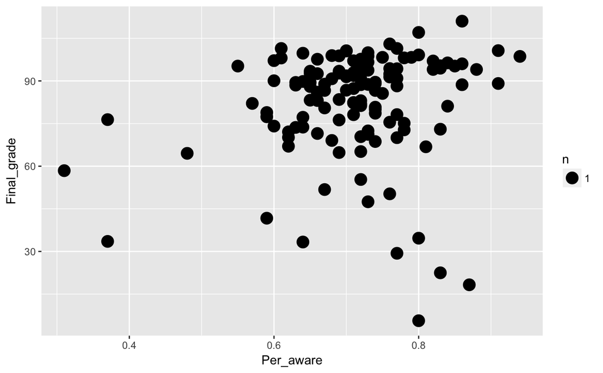

```r
#Percentage of correct homework responses, Final course grade
ggplot(MasterData, aes(Per_aware,Final_grade))+ geom_point() + stat_sum(aes(group = 1))
```

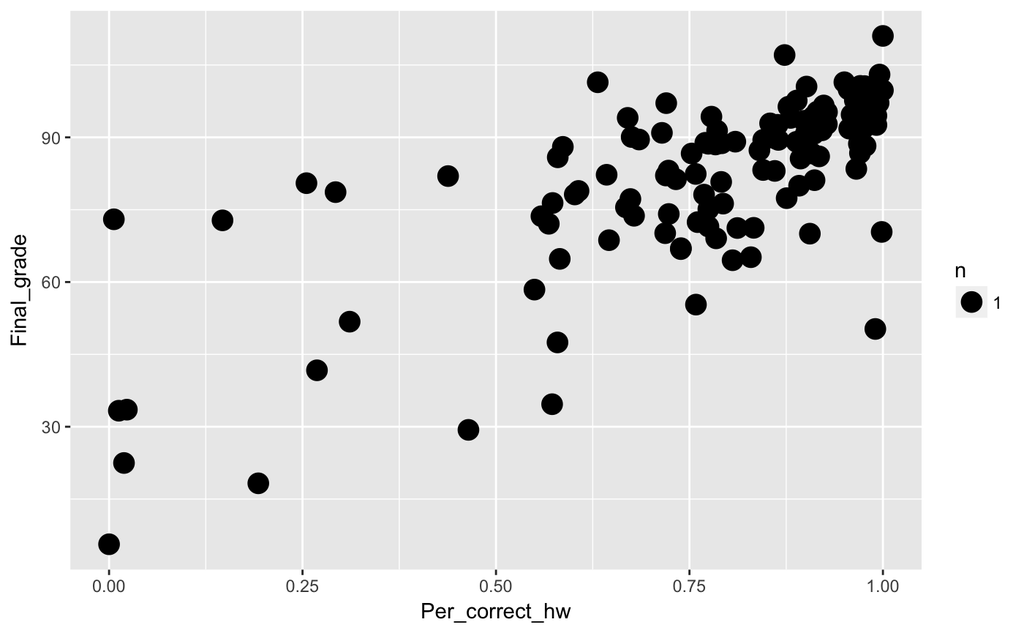

```r
#Percentage of correct homework responses, Final course grade
ggplot(MasterData, aes(Per_correct_hw,Final_grade))+ geom_point() + stat_sum(aes(group = 1))
```

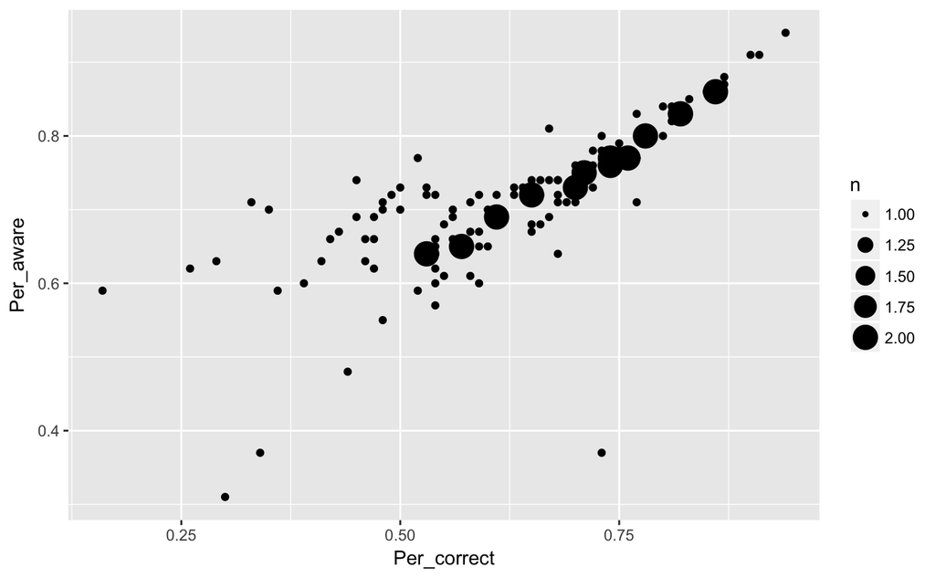

```r
#Percentage of correct LearnSmart responses, Percentage of awareness of correct/incorrect responses
ggplot(MasterData, aes(Per_correct,Per_aware))+ geom_point() + stat_sum(aes(group = 1))
```

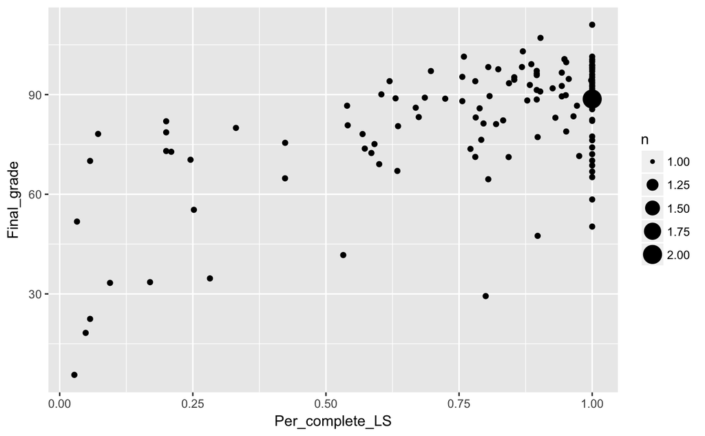

```r
#Percentage of completion of assigned LearnSmart activities, Final course grade
ggplot(MasterData, aes(Per_complete_LS,Final_grade))+ geom_point() + stat_sum(aes(group = 1))
```

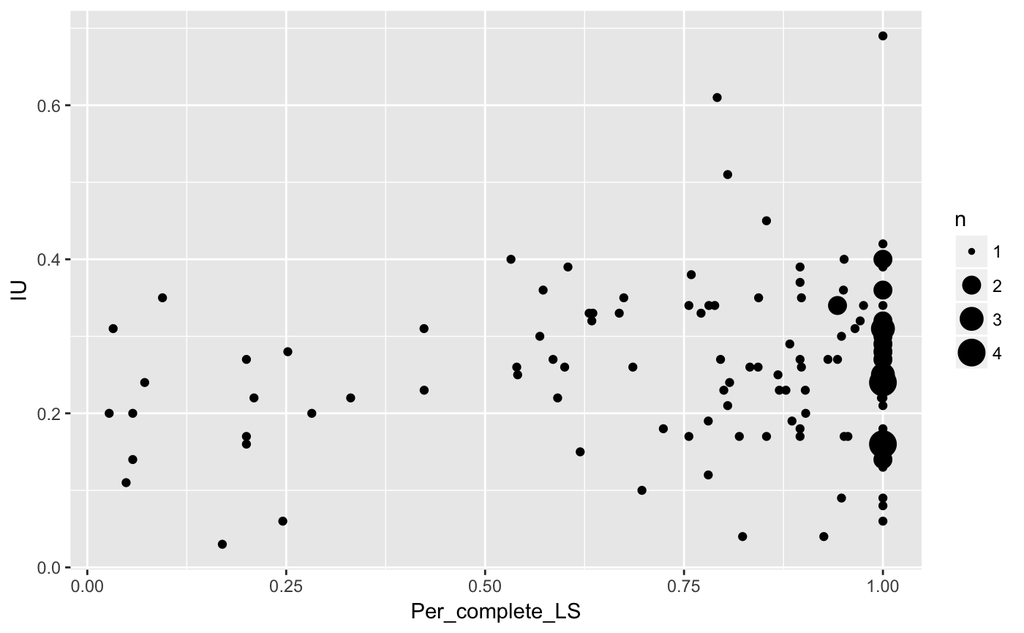

```r
#Percentage of completion of assigned LearnSmart activities, Percentage of incorrect and unaware LearnSmart responses
ggplot(MasterData, aes(Per_complete_LS,IU))+ geom_point() + stat_sum(aes(group = 1))
```

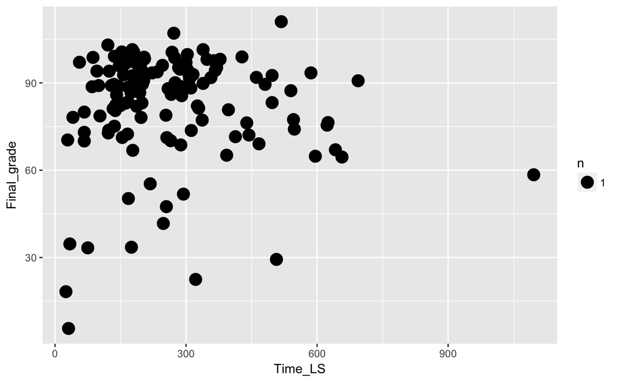

```r
#Time spent on LearnSmart adaptive activities, Final course grade
ggplot(MasterData, aes(Time_LS,Final_grade))+ geom_point() + stat_sum(aes(group = 1))
```

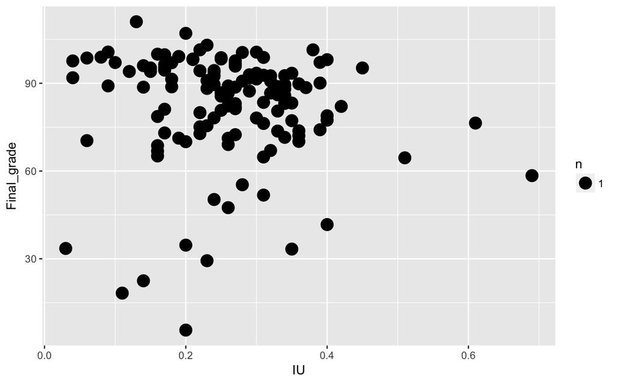

```r
#Percentage of incorrect and unaware LearnSmart responses, Final course grade
ggplot(MasterData, aes(IU,Final_grade))+ geom_point() + stat_sum(aes(group = 1))
```

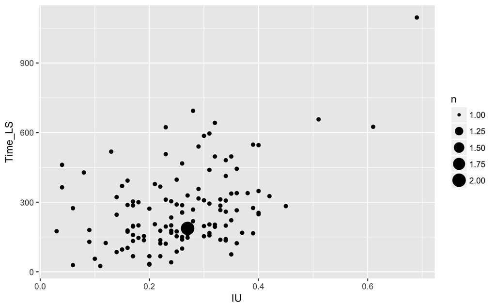

```r
#Percentage of incorrect and unaware LearnSmart responses, Time spent on LearnSmart adaptive activities
ggplot(MasterData, aes(IU,Time_LS))+ geom_point() + stat_sum(aes(group = 1))
```

#### Expected Relationships Between Variables

Some intuitive relationships between variables were evident in the data:

- Time spent on homework is correlated with percent of correct homework answers. Yet, it seems that there is a significant portion of students who get better return on their time investment than others which may indicate that other factors are involved in being correct on homework questions and not just time.
- Time spent on homework and time spent on Learn Smart (LS) are correlated as expected. Those who spent little time on one are likely to spend little time on the other.
- Percent correct on homework assignments is correlated with higher final grade. People who succeed in one are likely to succeed in the other.
- Perhaps the most salient correlation was found between percent of correct answers on LS and percent of correctly noting whether you know the answer or not. This was hypothesized before the analysis phase by the group as a potential obstacle for struggling students: not being aware of their weak spots. This correlation provides a fertile ground for further analysis and suggests potential avenues for Trent to support those students.

### Scaling the Data

We scaled the model variables and created a new data frame for clustering. We made sure that the variables were scaled as expected (mean = 0, sd = 1).

```r
#Create new data frame for scaled data, removing non-clustering variables
ScaledData<-as.data.frame(cbind(MasterData[,1:3],scale(select(MasterData, Final_grade:Per_complete_LS))))
#Validating scaling by looking at means and standard deviations of the scaled columns
sapply(ScaledData[,4:12], mean)
```

```
    Final_grade              IU     Per_correct       Per_aware         Time_hw       Time_pron         Time_LS
   5.843135e-17   -1.133857e-16    2.872520e-16   -4.121555e-16   -3.776554e-17    5.052708e-17    8.279565e-17
 Per_correct_hw Per_complete_LS
   2.015534e-16    4.870925e-18
```

```r
sapply(ScaledData[,4:12], sd)
```

```
    Final_grade              IU     Per_correct       Per_aware         Time_hw       Time_pron         Time_LS
              1               1               1               1               1               1               1
 Per_correct_hw Per_complete_LS
              1               1
```

### Determining the Number of Meaningful Clusters

We started out by creating a WSS plot. The results showed promise for a 3 or 5 cluster solution. We used the kmeans model to explore 3, 4, and 5 cluster solutions.

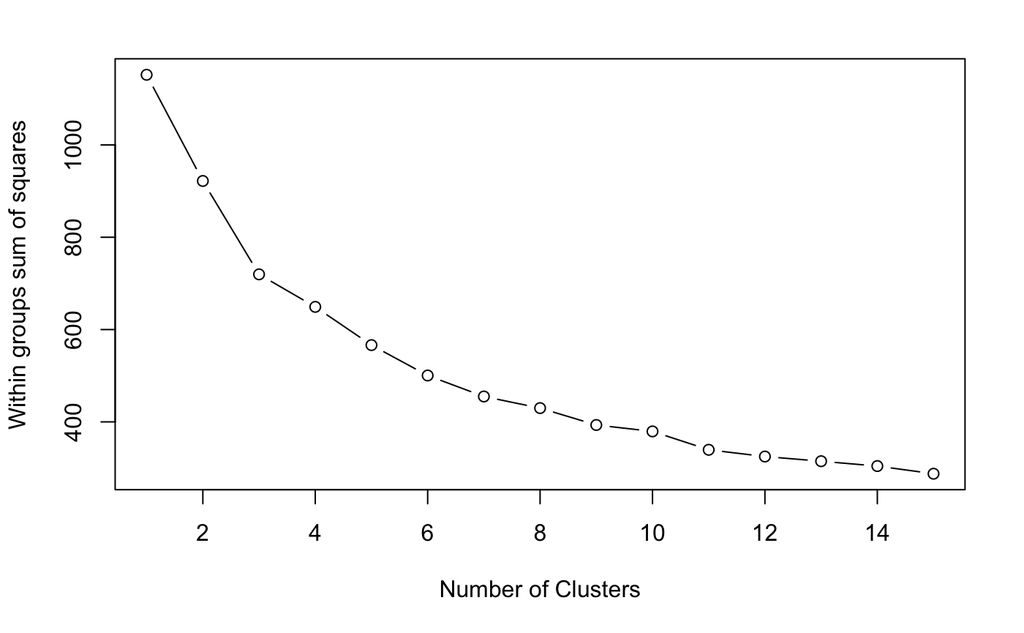

```r
#Creating the Within Group Sum of Squares function
wssplot <- function(data, nc=15, seed=1234){
  wss <- (nrow(data)-1)*sum(apply(data,2,var))
  for (i in 2:nc){
    set.seed(seed)
    wss[i] <- sum(kmeans(data, centers=i)$withinss)}
  plot(1:nc, wss, type="b", xlab="Number of Clusters",
       ylab="Within groups sum of squares")}
#Create the WSS Graph
wssplot(ScaledData[,4:12],nc=15,seed=1234)
```

### Model Outcomes

#### **Three Clusters:**

```r
#Create and examine several different possible cluster solutions
threeclusterkmeans<-kmeans(ScaledData[,4:12], 3, nstart=10)
threeclusterkmeans
```

```
K-means clustering with 3 clusters of sizes 15, 68, 46

Cluster means:
  Final_grade         IU Per_correct  Per_aware     Time_hw   Time_pron    Time_LS Per_correct_hw Per_complete_LS
1 -1.66048356 -0.4683417   0.4338804  0.2462526 -1.34682486 -0.38218605 -0.7236692   -2.050320950      -2.0744039
2  0.35681501 -0.5420303   0.4596331  0.5090781  0.02322455 -0.03493209 -0.2628125    0.450550769       0.2919678
3  0.01399637  0.9539823  -0.8209404 -0.8328501  0.40485007  0.17626462  0.6244845    0.002551347       0.2448315

Clustering vector:
  [1] 3 2 2 2 1 3 3 3 2 1 3 1 2 1 3 2 2 2 1 2 2 3 2 3 1 1 2 2 3 2 2 2 1 2 3 2 1 3 3 1 3 3 3 3 3 3 2 2 2 2 3 3 3 2 2 3 3 3 2 1 2
 [62] 2 3 2 2 3 2 2 1 2 2 2 2 2 3 3 3 2 2 3 2 2 2 3 2 2 3 2 1 3 3 3 2 2 1 2 2 2 3 2 2 2 3 3 2 2 2 2 2 2 3 1 3 2 2 3 3 2 2 2 2 2
[123] 3 3 3 2 2 2 3

Within cluster sum of squares by cluster:
[1] 108.0055 317.0107 294.2538
 (between_SS / total_SS =  37.6 %)

Available components:

[1] "cluster"      "centers"      "totss"        "withinss"     "tot.withinss" "betweenss"    "size"         "iter"
[9] "ifault"
```

Reviewing the outcomes from the 3 models raised some issues we needed to address. The three cluster solution painted a picture in which 2 clusters are doing well, while one smaller cluster contained students who seemed not to engage with the course’s online materials. This seemed too simplistic (either you’re not working enough or you are doing just fine). Trent knows he has students engaging with the course that do not achieve the same final outcomes as others, especially when comparing the time they work on their assignments to the time spent by other students. We decided that a 3 cluster solution would not be meaningful enough for Trent.

#### **Five Clusters:**

```r
fiveclusterkmeans<-kmeans(ScaledData[,4:12], 5, nstart=10)
fiveclusterkmeans
```

```
K-means clustering with 5 clusters of sizes 15, 8, 48, 8, 50

Cluster means:
  Final_grade         IU Per_correct  Per_aware     Time_hw  Time_pron    Time_LS Per_correct_hw Per_complete_LS
1  -1.6604836 -0.4683417   0.4338804  0.2462526 -1.34682486 -0.3821861 -0.7236692     -2.0503209     -2.07440393
2  -0.8958391  1.8145097  -1.6624902 -1.8274568  0.38576944  1.1720791  2.0226886     -0.6364557     -0.03588736
3   0.2330110  0.5268289  -0.6437720 -0.4944191  0.32459226 -0.2942711  0.1758020      0.2001563      0.34190903
4   0.5402091 -0.6773911   0.5264911  0.6671668  0.71442790  3.0706229  0.7154549      0.7003101      0.44258213
5   0.3313553 -0.5471922   0.6696168  0.5864130 -0.08359268 -0.2816763 -0.3897721      0.4127295      0.22901734

Clustering vector:
  [1] 3 3 5 3 1 3 3 3 5 1 3 1 5 1 3 5 5 5 1 5 5 3 5 3 1 1 5 4 4 4 5 5 1 3 2 4 1 3 2 1 2 4 3 2 4 3 5 5 5 5 3 3 3 5 5 3 3 3 3 1 5
 [62] 5 2 5 5 3 5 5 1 5 3 4 5 5 3 3 3 5 3 3 5 5 5 3 5 3 2 5 1 3 3 3 3 5 1 5 3 5 2 4 5 5 3 3 3 5 3 5 5 5 3 1 3 3 5 3 3 5 5 5 5 5
[123] 2 3 3 3 5 5 3

Within cluster sum of squares by cluster:
[1] 108.00545  67.74078 174.55641  48.06331 160.84719
 (between_SS / total_SS =  51.5 %)

Available components:

[1] "cluster"      "centers"      "totss"        "withinss"     "tot.withinss" "betweenss"    "size"         "iter"
[9] "ifault"
```

We moved on to look at what we had initially considered as the second promising point. The additional cluster primarily broke apart students doing very well and two smaller groups emerged: a) Those who spend more time in the online workbook activities, thereby earning higher grades, and b) those who earn high grades in spite of spending less time in the online workbook. While insightful, the added granularity among high performing students is less useful. Those students already seem to know how to succeed in the course, so additional tailoring or intervention would be less impactful than focusing on struggling students.

For the purposes of this project, we decided to focus on the four cluster solution as it captures a larger group of high effort/low outcome students.

#### **Four Clusters:**

```r
fourclusterkmeans<-kmeans(ScaledData[,4:12], 4, nstart=10)
fourclusterkmeans
```

```
K-means clustering with 4 clusters of sizes 15, 37, 19, 58

Cluster means:
  Final_grade         IU Per_correct  Per_aware     Time_hw  Time_pron    Time_LS Per_correct_hw Per_complete_LS
1  -1.6964014 -0.6400324   0.4608217  0.2805430 -1.33097412 -0.3821861 -0.7669705     -1.8427475      -2.1677251
2   0.5572135 -0.7840533   0.9818083  0.8836826  0.07144945  0.2390765 -0.2894854      0.5519276       0.4797214
3  -0.3507149  1.1769446  -0.9840832 -1.1188646  0.87451648  1.0314872  1.5405665     -0.1017225       0.1292924
4   0.1981501  0.2801468  -0.4231319 -0.2697582  0.01215809 -0.3915741 -0.1216422      0.1578038       0.2122350

Clustering vector:
  [1] 3 4 4 4 1 4 4 4 1 1 4 1 2 1 3 2 2 2 1 4 2 4 4 4 1 1 4 2 3 2 2 4 1 4 3 2 1 3 3 1 3 3 3 3 3 4 2 4 2 2 4 4 4 4 2 3 4 4 4 1 2
 [62] 2 3 4 4 4 2 4 4 2 4 2 2 2 4 3 4 4 4 4 2 4 2 4 4 4 3 4 1 4 4 4 4 2 1 2 4 2 3 2 2 2 4 4 4 4 4 4 2 2 3 1 4 4 4 4 3 2 2 2 2 2
[123] 3 4 4 4 2 2 4

Within cluster sum of squares by cluster:
[1] 111.4874 159.6486 162.9807 194.7688
 (between_SS / total_SS =  45.4 %)

Available components:

[1] "cluster"      "centers"      "totss"        "withinss"     "tot.withinss" "betweenss"    "size"         "iter"
[9] "ifault"
```

## Visualizing the Clusters

### Assigning Observations to Clusters

```r
#Assign the clusters for each observation for k=3,4 to a new dataframe
Clusters<-data.frame(ScaledData, as.factor(threeclusterkmeans$cluster), as.factor(fourclusterkmeans$cluster))
names(Clusters) <- c("ID","Sex","Language","Final_grade","IU","Per_correct","Per_aware","Time_hw","Time_pron","Time_LS","Per_correct_hw","Per_complete_LS","ClusterToThree","ClusterToFour")
```

### Going Back to the Variables

We went back to the visualizaitons we started with.  
This second round includes cluster information, so we can now see how the clusters differ on those dimensions of interest.

We reviewed again the chart we looked at before clustering, focusing mainly on the surprising ones. We can say that the clustering algorithm did seem to differntiate between students effectively on most dimensions, especially between the low outcome and the average/high outcome students.

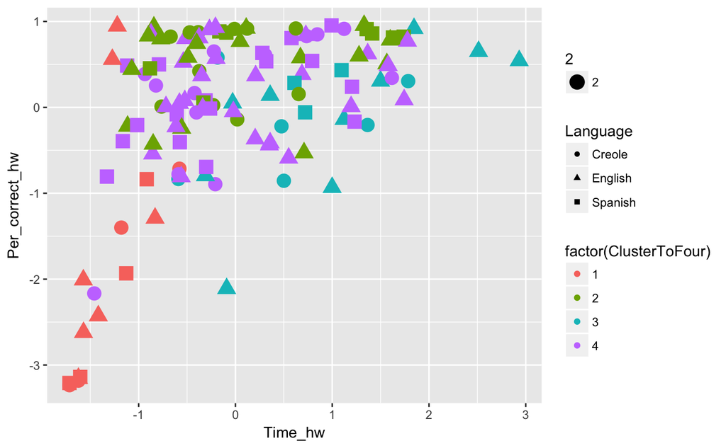

```r
#Graph the different solutions - Four Clusters.
#Shapes indicate Language Background. To change which variable is marked by shape, change the name of the variable in "shape=Language
ggplot(Clusters, aes(Time_hw,Per_correct_hw, group = factor(ClusterToFour))) + geom_point((aes(size=2,shape=Language, color = factor(ClusterToFour))))
```

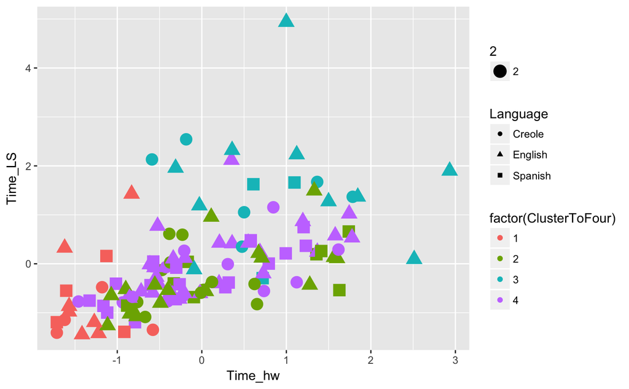

```r
ggplot(Clusters, aes(Time_hw,Time_LS, group = factor(ClusterToFour))) + geom_point((aes(size=2,shape=Language, color = factor(ClusterToFour))))
```

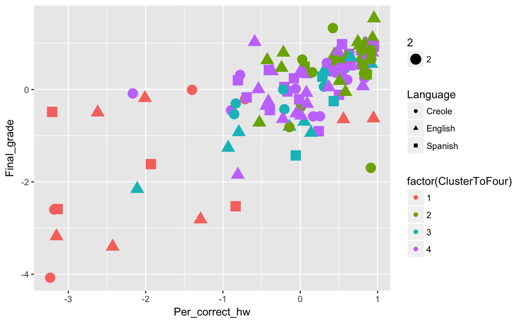

```r
ggplot(Clusters, aes(Per_correct_hw,Final_grade, group = factor(ClusterToFour))) + geom_point((aes(size=2,shape=Language, color = factor(ClusterToFour))))
```

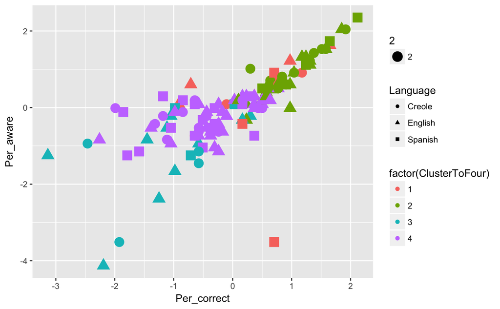

```r
ggplot(Clusters, aes(Per_correct,Per_aware, group = factor(ClusterToFour))) + geom_point((aes(size=2,shape=Language, color = factor(ClusterToFour))))
```

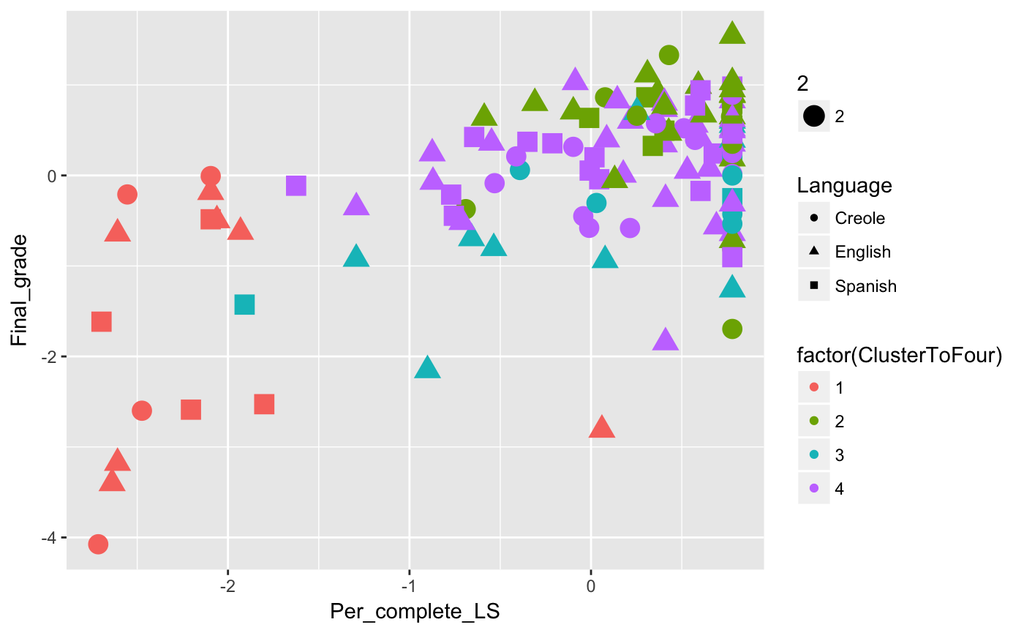

```r
ggplot(Clusters, aes(Per_complete_LS,Final_grade, group = factor(ClusterToFour))) + geom_point((aes(size=2,shape=Language, color = factor(ClusterToFour))))
```

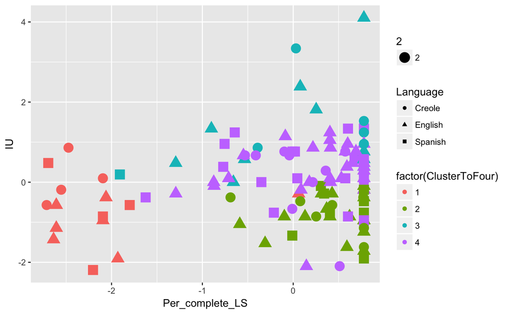

```r
ggplot(Clusters, aes(Per_complete_LS,IU, group = factor(ClusterToFour))) + geom_point((aes(size=2,shape=Language, color = factor(ClusterToFour))))
```

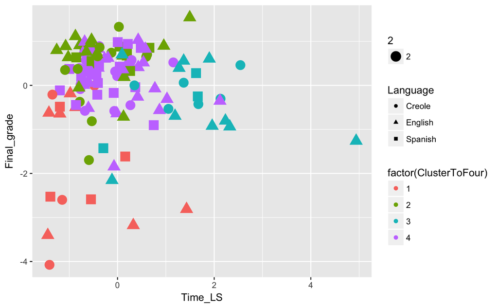

```r
ggplot(Clusters, aes(Time_LS,Final_grade, group = factor(ClusterToFour))) + geom_point((aes(size=2,shape=Language, color = factor(ClusterToFour))))
```

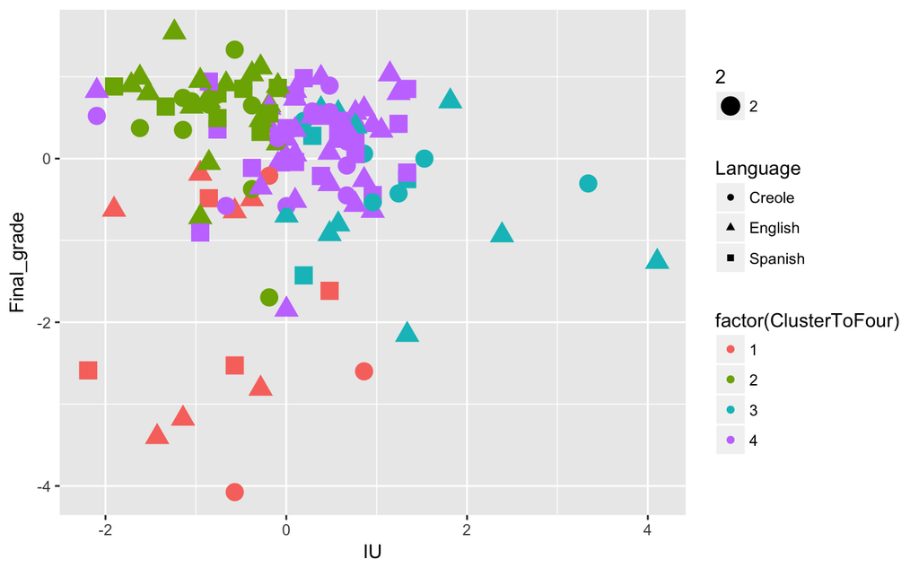

```r
ggplot(Clusters, aes(IU,Final_grade, group = factor(ClusterToFour))) + geom_point((aes(size=2,shape=Language, color = factor(ClusterToFour))))
```

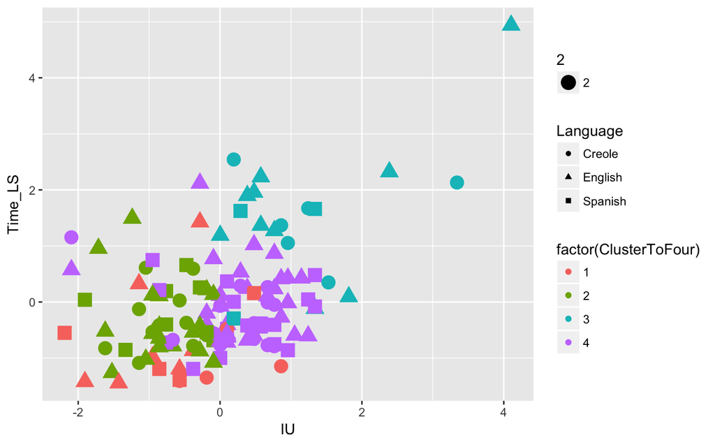

```r
ggplot(Clusters, aes(IU,Time_LS, group = factor(ClusterToFour))) + geom_point((aes(size=2,shape=Language, color = factor(ClusterToFour))))
```

## Cluster Statistics

We wanted to review the actual values of the cluster centroids and not just the scaled values.

```r
# Adding the clusters to the unscaled df
UnscaledClusters<-data.frame(MasterData, as.factor(threeclusterkmeans$cluster), as.factor(fourclusterkmeans$cluster))
names(UnscaledClusters) <- c("ID","Sex","Language","Final_grade","IU","Per_correct","Per_aware","Time_hw","Time_pron","Time_LS","Per_correct_hw","Per_complete_LS","ClusterToThree","ClusterToFour")
MeanTable <- data.frame("Final_grade"=double(),"IU"=double(),"Per_correct"=double(),"Per_aware"=double(),"Time_hw"=double(),"Time_pron"=double(),"Time_LS"=double(),"Per_correct_hw"=double(),"Per_complete_LS"=double())
```

```r
for (i in 1:4){
    MeanTable [i,1]<- mean(UnscaledClusters$Final_grade[UnscaledClusters$ClusterToFour==i])
    MeanTable [i,2]<- mean(UnscaledClusters$IU[UnscaledClusters$ClusterToFour==i])
    MeanTable [i,3]<- mean(UnscaledClusters$Per_correct[UnscaledClusters$ClusterToFour==i])
    MeanTable [i,4]<- mean(UnscaledClusters$Per_aware[UnscaledClusters$ClusterToFour==i])
    MeanTable [i,5]<- mean(UnscaledClusters$Time_hw[UnscaledClusters$ClusterToFour==i])
    MeanTable [i,6]<- mean(UnscaledClusters$Time_pron[UnscaledClusters$ClusterToFour==i])
    MeanTable [i,7]<- mean(UnscaledClusters$Time_LS[UnscaledClusters$ClusterToFour==i])
    MeanTable [i,8]<- mean(UnscaledClusters$Per_correct_hw[UnscaledClusters$ClusterToFour==i])
    MeanTable [i,9]<- mean(UnscaledClusters$Per_complete_LS[UnscaledClusters$ClusterToFour==i])
}
row.names(MeanTable) <- c("Cluster 1", "Cluster 2", "Cluster 3", "Cluster 4")
MeanTable
```

|  | Final_grade | IU | Per_correct | Per_aware | Time_hw | Time_pron | Time_LS | Per_correct_hw | Per_complete_LS |
| --- | --- | --- | --- | --- | --- | --- | --- | --- | --- |
| Cluster 1 | 50.26867 | 0.1926667 | 0.6940000 | 0.7386667 | 248.800 | 21.80000 | 138.6000 | 0.3323313 | 0.1797767 |
| Cluster 2 | 92.55784 | 0.1775676 | 0.7713514 | 0.7972973 | 1157.162 | 88.43243 | 218.7297 | 0.9040180 | 0.9168398 |
| Cluster 3 | 75.52053 | 0.3831579 | 0.4794737 | 0.6026316 | 1677.316 | 173.42105 | 525.8421 | 0.7479705 | 0.8192785 |
| Cluster 4 | 85.82000 | 0.2891379 | 0.5627586 | 0.6851724 | 1118.759 | 20.79310 | 246.8966 | 0.8099278 | 0.8423701 |

From analyzing the unscaled means we get a stronger sense of the differences between the clusters in meaningful terms. For example, the High Effort / Low Outcome students (Cluster 3) are spending on average more than double the amount of time on LS (500+ mins vs ~225 mins) than other groups and 50% more time on homework (~1700 mins vs ~1100 mins) than other groups. Yet they are correct less than 50% of the time and only unaware of being incorrect for more than a third of the questions.

This view of the data also shows general trends across the class, namely that correctness improves from LearnSmart to homework activities. This makes sense given that LS is assigned as formative assessment and review between classes while homework is due at the end of a unit as a form of summative assessment.

## Demographic Analysis

In addition, we wanted to see if some populations are over-represented in some of the clusters.

```r
#creating languages vector and proportion tables for both demogrpahic variables
langs <- c("English","Spanish","Creole")
prop.table(table(Clusters$Language,Clusters$ClusterToFour),1)[c(2,3,6),] # within language cluster proportion
```

```
                  1         2         3         4
  Creole  0.1176471 0.3235294 0.1764706 0.3823529
  English 0.1111111 0.2857143 0.1587302 0.4444444
  Spanish 0.1250000 0.2500000 0.0937500 0.5312500
```

```r
prop.table(table(Clusters$Language,Clusters$ClusterToFour),2)[c(2,3,6),] # within cluster language proportion
```

```
                  1         2         3         4
  Creole  0.2666667 0.2972973 0.3157895 0.2241379
  English 0.4666667 0.4864865 0.5263158 0.4827586
  Spanish 0.2666667 0.2162162 0.1578947 0.2931034
```

```r
prop.table(table(Clusters$Sex,Clusters$ClusterToFour),1) # within sex cluster proportion
```

```
            1         2         3         4
  f 0.1111111 0.3333333 0.1555556 0.4000000
  m 0.1282051 0.1794872 0.1282051 0.5641026
```

```r
prop.table(table(Clusters$Sex,Clusters$ClusterToFour),2) # within cluster sex proportion
```

```
            1         2         3         4
  f 0.6666667 0.8108108 0.7368421 0.6206897
  m 0.3333333 0.1891892 0.2631579 0.3793103
```

**Tables 1 & 2: Distribution of language background across/within clusters** Given the ~1:2:1 ratio of Creole, English, and Spanish within this sample, the even distributions of language backgrounds within most clusters show that linguistic background has little impact on course performance - a bit of a surprising result given anecdotal evidence. One exception, however, may be that within this sample, those with a background in Spanish were less likely to be in the High Effort/Low Outcome group (Cluster 3). Given that those students were characterized by a low awareness of being incorrect, it could be that Spanish speakers are more cognizant of the differences between French and their native language than speakers of English or Haitian Creole.

**Tables 3 & 4: Distribution of sex across/within clusters** The sample contains a ~2:1 ratio of females to males, thus sex does not appear to affect the low outcome cluster distributions in a meaningful way.

## 5) Conclusion

Based on our analysis, the answer to the question we have asked is yes, student practice behaviors and performance outcomes from the textbook’s online workbook can be used to meaningfully cluster students. We also feel that given the specific variables we used to answer our question, we were able to identify the challenges that different student groups face. Therefore, the data and our analysis can provide insights into possible actionable steps Trent could take to help each student cluster. We are confident in the analysis we conducted but, also do recognize that the online workbook activities only make up for 25% of the course grade and therefore, we could be missing other important pieces of the puzzle. Within different student clusters, there might be multiple reasons for low motivation or low grades. We would have to go deeper in to other aspects of student behavior such as class participation and other assignment grades for a more refined conclusion.

## 6) Reflection

One of the challenges we encountered was narrowing down on questions that would provide Trent with meaningful insights to help his students, in future courses. The breadth of data that was available required us to take a decision very early on about which variables we wish to include in our analysis, to avoid downloading and cleaning data that would not help in answering our questions. We mostly relied on each other’s strenghts for help, with team members who have stronger R skills helping those who were struggling with coding. If we had more time to keep working on the project we would probably conduct a wider analysis, incorporating additional variables to help paint a more holistic picture of the students and their learning behaviors. That siad, we feel that the results we were able to obtain are meaningful and could help Trent in better tailoring his class to support the needs of his students.